# Final Visiualization

Min Gao

2024-06-06

#### Presentation slides

The dataset provides insights into the real estate market, including trends in property prices, property types, and tax rates across different localities and years.In this lab, I analyzed property sales data to understand trends in sale price across different localities and properties.

This dataset contains information about real estate property transactions. Each row represents a single property transaction.

Here are all the column names in the dataset:

Date: The date when the property transaction occurred. Year: The year of the property transaction. Locality: The locality or area where the property is located. Estimated Value: The estimated value of the property. Sale Price: The actual sale price of the property. Property: The type of property (e.g., Single Family). Residential: Indicates whether the property is residential or not. Num_rooms: The number of rooms in the property. Num_bathrooms: The number of bathrooms in the property. Carpet Area: The carpet area of the property. Property Tax Rate: The property tax rate applicable to the property. Face: The facing direction of the property (e.g., North, South, East).

## https://www.kaggle.com/datasets/subhiarjaria09/real-estate-property-transactions-dataset

```r
data <- read_csv("data/V3.csv")
data$Property[data$Property == '?'] <- NA
cleaned_data <- data[!is.na(data$Property), ]
transaction <- cleaned_data %>% rename('estimated_value' = 'Estimated Value','sale_price'='Sale Price')
glimpse(transaction)
```

```
## Rows: 8,212
## Columns: 12
## $ Date              <date> 2009-01-02, 2009-01-02, 2009-01-02, 2009-01-02, 200…
## $ Year              <dbl> 2009, 2009, 2009, 2009, 2009, 2009, 2009, 2009, 2009…
## $ Locality          <chr> "Waterbury", NA, "Waterbury", "Norwalk", "Bridgeport…
## $ estimated_value   <dbl> 111440, 73080, 50540, 571060, 4775276, NA, NA, 20888…
## $ sale_price        <dbl> 185000, 152000, 105000, 1000000, 272900, 1340000, 41…
## $ Property          <chr> "Single Family", "Single Family", "Single Family", "…
## $ Residential       <chr> "Detached House", "Detached House", "Detached House"…
## $ num_rooms         <dbl> 3, 3, 3, 3, 3, 3, 4, 3, 4, 3, 3, 3, 3, 4, 4, 3, 4, 3…
## $ num_bathrooms     <dbl> 3, 1, 1, 2, 1, 1, 3, 2, 4, 1, 1, 2, 1, 2, 2, 1, 3, 2…
## $ carpet_area       <dbl> 996, 935, 951, NA, 971, 936, 1498, 1063, 1471, 960, …
## $ property_tax_rate <dbl> 1.025953, 1.025953, 1.025953, 1.025953, 1.025953, 1.…
## $ Face              <chr> "South", "North", "East", "South", "East", "North", …
```

```r
df1 <- transaction %>% filter(Locality=='Greenwich'|Locality=='Fairfield'|Locality=='Waterbury'|Locality=='West Hartford')
df_lc <- df1 %>% group_by(Year, Locality) %>%
  summarize(avg_price = mean(sale_price, na.rm = TRUE))
df <- na.omit(df_lc)
```

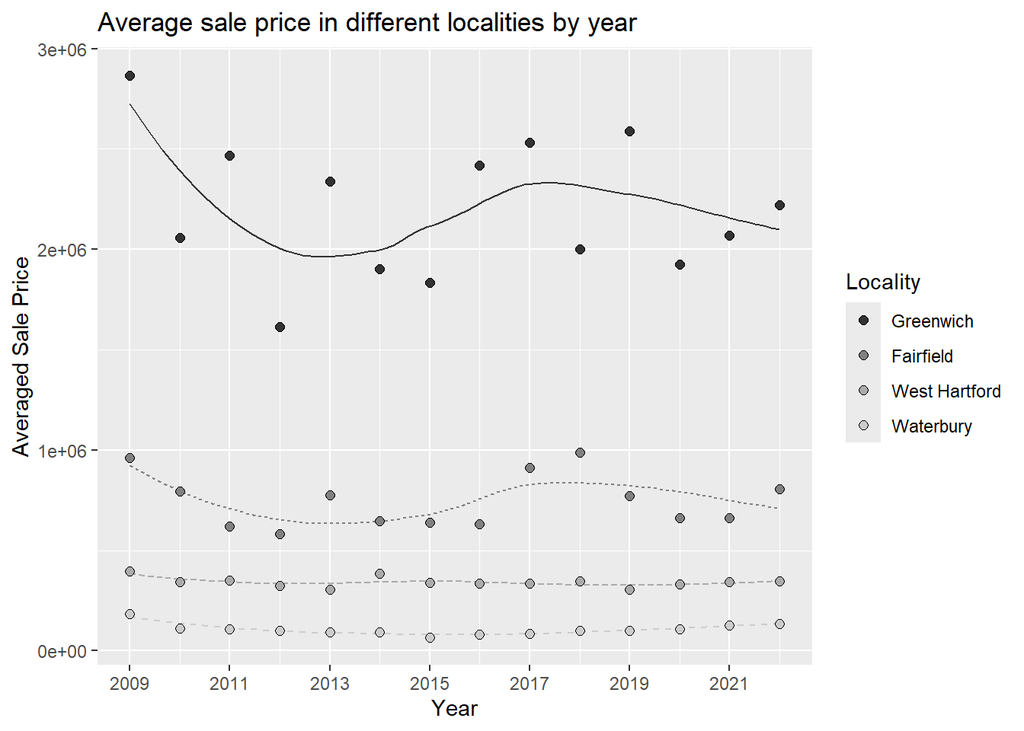

```r
ggplot(df_lc, aes(x = Year, y = avg_price,
                   fill = fct_reorder2(Locality, Year, avg_price))) +
  geom_smooth(aes(color = fct_reorder2(Locality, Year, avg_price),
                  lty = fct_reorder2(Locality, Year, avg_price)),
              se = FALSE, lwd = .5, show.legend = FALSE) +
  geom_point(size = 2, shape = 21) +
  labs(x = "Year",
       y = "Averaged Sale Price",
       fill = "Locality",
       title = "Average sale price in different localities by year") +
  scale_x_continuous(breaks=seq(min(df_lc$Year), max(df_lc$Year), by=2))+
  scale_fill_grey(start = 0.2, end = 0.8) +
  scale_color_grey(start = 0.2, end = 0.8)
```

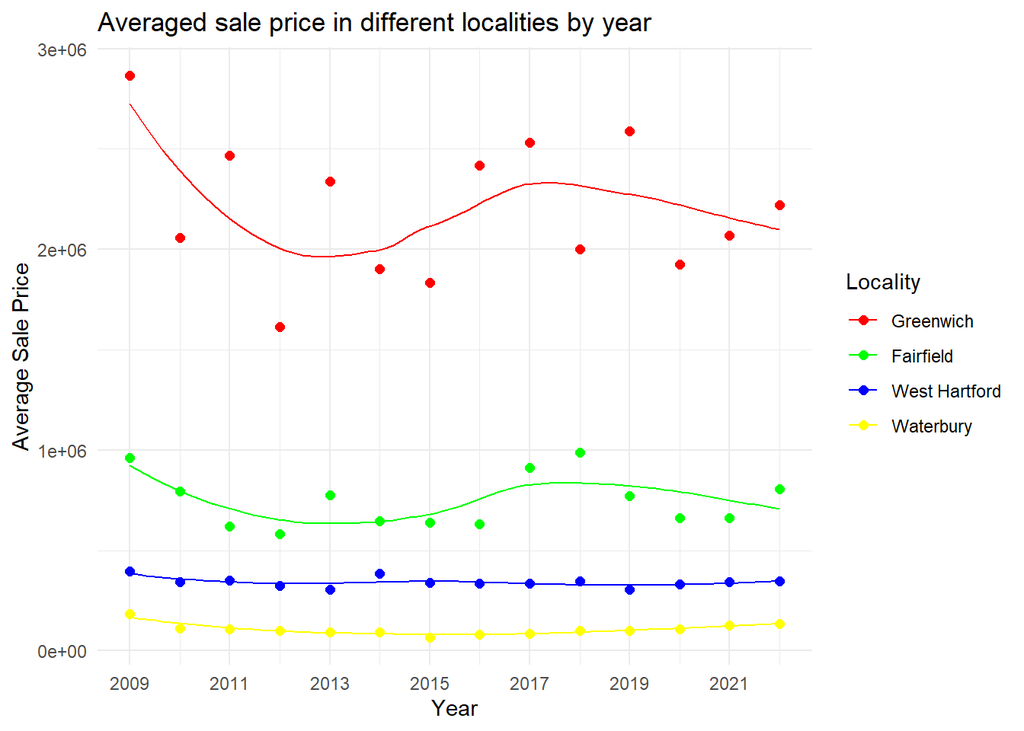

```r
ggplot(df, aes(x = Year,
                   y = avg_price,
                   color = fct_reorder2(Locality, Year, avg_price))) +
  geom_smooth(se = FALSE, lwd = 0.5) +
  geom_point(size = 2) +
  labs(x = "Year",
       y = "Average Sale Price",
       color = "Locality",
       title = "Averaged sale price in different localities by year")+
  scale_x_continuous(breaks=seq(min(df_lc$Year), max(df_lc$Year), by=2))+
  scale_colour_manual(values = c("#ff0000", "#00ff00", "#0000ff",
                        "#ffff00"))+
  theme_minimal()
```

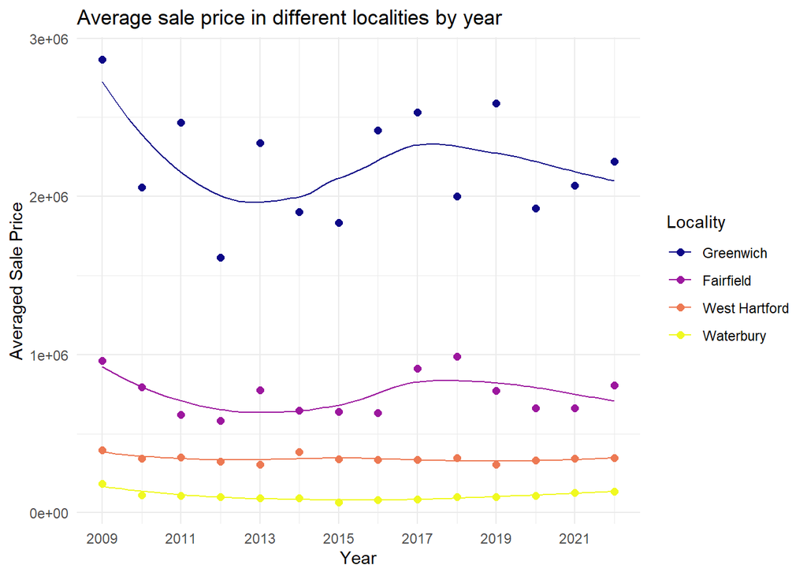

```r
ggplot(df, aes(x = Year,
                   y = avg_price,
                   color = fct_reorder2(Locality, Year, avg_price))) +
 geom_smooth(se = FALSE, lwd = 0.5) +
  geom_point(size = 2) +
  labs(x = "Year",
       y = "Averaged Sale Price",
       color = "Locality",
       title = "Average sale price in different localities by year")+
  scale_x_continuous(breaks=seq(min(df$Year), max(df$Year), by=2))+
  scale_color_viridis_d(option = "plasma") +
  theme_minimal()
```

```r
df_prop <- transaction %>%
  group_by(Year, Property) %>%
  summarize(avg_price = mean(sale_price, na.rm = TRUE))
df_prop <- na.omit(df_prop)
```

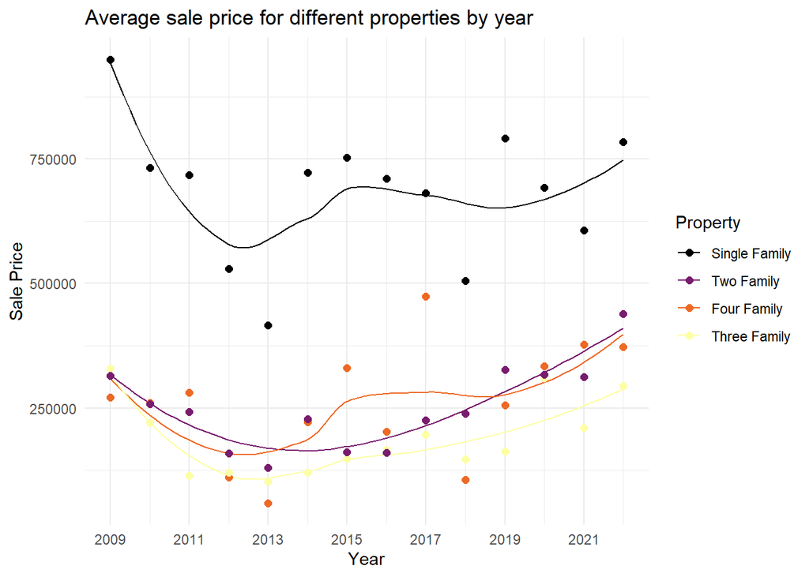

```r
ggplot(df_prop, aes(x = Year,
                   y = avg_price,
                   color = fct_reorder2(Property, Year, avg_price))) +
 geom_smooth(se = FALSE, lwd = 0.5) +
  geom_point(size = 2) +
  labs(x = "Year",
       y = "Sale Price",
       color = "Property",
       title = "Average sale price for different properties by year")+
  scale_x_continuous(breaks=seq(min(df$Year), max(df$Year), by=2))+
  scale_color_viridis_d(option = "inferno") +
  theme_minimal()
```

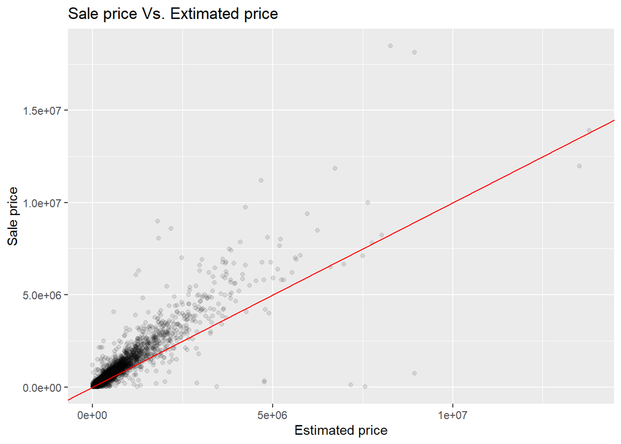

```r
ggplot(transaction, aes(estimated_value, sale_price)) +
  geom_point(alpha = .1, na.rm = TRUE) +
  geom_abline(intercept = c(0,0), colour = "red") +
  labs(x = "Estimated price", y = "Sale price") +
  ggtitle("Sale price Vs. Extimated price")
```

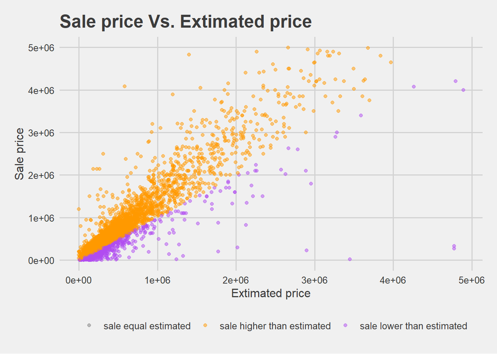

```r
price_data <- transaction %>%
  filter(sale_price < 5e+06, estimated_value < 5e+06) %>%
  mutate(price_ratio = sale_price / estimated_value,
         price_cat = case_when(
           price_ratio > 1 ~ "sale higher than estimated",
           price_ratio < 1 ~ "sale lower than estimated",
           price_ratio == 1 ~ "sale equal estimated"
         ))
ggplot(price_data, aes(x = estimated_value, y = sale_price, colour = price_cat)) +
  geom_point(alpha = .5) +
  ggtitle("Sale price Vs. Extimated price") +
  scale_colour_manual(name = "",
                      values = c("gray50", "#FF9900", "#B14CF0")) +
  theme_fivethirtyeight() +
  theme(axis.title = element_text()) +
  labs(x = "Extimated price", y = "Sale price")
```

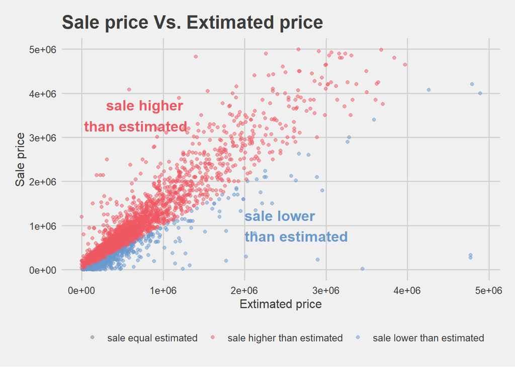

```r
price_data <- transaction %>%
  filter(sale_price < 5e+06, estimated_value < 5e+06) %>%
  mutate(price_ratio = sale_price / estimated_value,
         price_cat = case_when(
           price_ratio > 1 ~ "sale higher than estimated",
           price_ratio < 1 ~ "sale lower than estimated",
           price_ratio == 1 ~ "sale equal estimated"
         ))
library(ggthemes)
ggplot(price_data, aes(x = estimated_value, y = sale_price, colour = price_cat)) +
  geom_point(alpha = .5) +
  ggtitle("Sale price Vs. Extimated price") +
  scale_colour_manual(name = "",
                      values = c("gray50", "#ee5863", "#6999cd")) +
  theme_fivethirtyeight() +
  theme(axis.title = element_text()) +
  labs(x = "Extimated price", y = "Sale price") +
  annotate(x = 1.3e+06, y = 3.5e+06, geom = "text",
           label = "sale higher \nthan estimated", color = "#ee5863",
           size = 5, family = "Lato", hjust = 1, fontface = 2) +
  annotate(x = 2e+06, y = 1e+06, geom = "text",
             label = "sale lower \nthan estimated", color = "#6999cd",
             size = 5, family = "Lato", hjust = 0, fontface = 2)
```